# We Rate Dogs Twitter Analysis - Data Wrangling Report

## Introduction

WeRateDogs is a Twitter account that rates people's dogs with humorous comments about the dog. These ratings almost always have a denominator of 10, while the numerators can be greater than 10. The numerators, though? Almost always greater than 10. 11/10, 12/10, 13/10, etc. Sometimes, they mention the breed of the dog in their tweets, and other times, they don’t. WeRateDogs has over 4 million followers and has received international media coverage.

## Project objectives

The main objectives of this project are to:

- Gather data from 3 different sources.
- Perform data wrangling (gathering, assessing and cleaning) on provided data sets
- Store, analyze, and visualize the wrangled data.
- Reporting on the data wrangling efforts, analysis and visualizations.

## Data Gathering

The dataset used in this project is an archive of all tweets from the Twitter account @dog_rates which was provided by Udacity. This archive contains basic tweet data for over 2000 tweets up till August 1, 2017. The Data Gathering process is comprises of 3 methods of gathering data:

- WeRateDogs Twitter archive: This 'twitter-archive-enhanced.csv' data was downloaded manually and loaded into a dataframe.
- Tweet image predictions: The ‘image_predictions.tsv’ was downloaded programmatically using Python Requests library.
- Additional data from the Twitter API: Each tweet's retweet count and favorites count are supposed to be queried from Twitter's API into a ‘tweet_json.txt’ file. However, due to my Twitter Developer account not being verified in time, I downloaded a JSON file containing the tweets which was provided by Udacity programmatically.

In order to make meaningful analysis out of the data, the data was first assessed and cleaned. In this phase, a number of observations were made. The observations and actions taken to clean the data is detailed below:

### Assessment

#### Quality issues

1. Non-descriptive column names. 'id' column in `tweets_df` dataframe should be 'tweet_id', 'full_text' column to 'tweet', 'created_at' should be 'timestamp', 'text' column in `data_archive` dataframe should also be 'tweet'.
2. HTML code present in `source` colummn in both data_archive and tweets_df dataframe.
3. Retweets present in both `data_archive` and `tweet_df` dataframe. They are prefixed with 'RT'.
4. Tweets without images present in both `data_archive` `tweet_df`.
5. Tweets with invalid names e.g 'a', 'actually', 'None'.
6. Wrong data type in tweet_id & source column. tweet_id represented as integer instead of string, source represented as object instead of category.
7. `rating_denominator`in `data_archive` contains value not equal to 10. E.g., the maximum value for `rating_denominator` is 170.
8. Missing values represented as 'None' instead of NaN.
9. `img_num` column in image_predictions dataframe not needed for analysis

#### Tidiness issues

1. Empty columns and columns with very little amount of data which iclude: `contributors`, `coordinates`, `geo`, `place`, `in_reply_to_status_id_basic`, `in_reply_to_user_id_basic`, `in_reply_to_screen_name`, `in_reply_to_status_id_extended`, `in_reply_to_status_id_str`, `in_reply_to_user_id_extended`, `in_reply_to_user_id_str`, `quoted_status`, `quoted_status_id`, `quoted_status_id_str`, `quoted_status_permalink`, `retweeted_status_id`, `retweeted_status_user_id`, `retweeted_status_id`, `retweeted_status`, `retweeted_status_timestamp`,`is_quote_status` in tweets_df and data_archive
2. data_archive, tweets_df and image_prediction should be merged
3. variable names as column names: 'doggo','floofer', 'pupper', 'puppo'
4. Predictions column should be one variable

### Data Cleaning

In the data cleaning process, first I made a copy of the 3 dataset before I started all data cleaning operations. The following steps were taken to clean the data:

1. Removed empty columns, columns with very little amount of data and columns with duplicate data like `contributors`, `coordinates`, `geo`, `place`, `in_reply_to_status_id_basic`, `in_reply_to_user_id_basic` etc.
2. Renamed `id` column in `tweets_df` to 'tweet_id', rename `full_text` column to 'tweet', `created_at` to timestamp. I renamed the `text` column in `data_archive` to 'tweet'
3. Merged all dataframes together into all_df before futher cleaning
4. Replaced all 'None' value to NaN.
5. Replaced values in the source columns with values like iPhone, Twitter Web Client, TweetDeck, Vine.
6. Converted `tweet_id` from integer to object data type, converted `source` column from object to category data type, `og_class` from object to Category data type. and `p1_dog`, `p2_dog`,`p3_dog` to bool data type.
7. Identified weets and removed them using regular expressions.
8. Removed rows without images. All rows which contained non-dog images were dropped.
9. Replaced all tweets with a rating_denominator not equal to 10 with 10.
10. Converted wrong names into NaN and replaced names that contained 'None' with NaN.
11. The doggo, floofer, pupper and pupper fields in the all_df dataframe was collapsed into a single column.
12. All prediction columns - p1, p2, p3 was collapsed into one single column.

### Results

The cleaned data contains 1685 rows and was saved into twitter_archive_master.csv file.

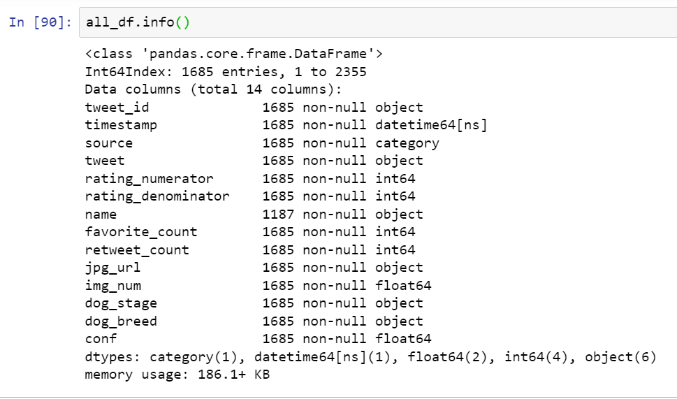